# Publishing eDNA data through GBIF-US & OBIS-USA

Stephen Formel

sformel@usgs.gov

Biogeographic Science Branch

Science Analytics and Synthesis (SAS)

**Resources for the OBIS/GBIF enthusiast**

[output not shown]

**Example DNA-Derived Datasets**

| Title | Platform | Link |
| --- | --- | --- |
| eDNA from Gulf of Mexico Ecosystems and Carbon Cruise 2021 (GOMECC-4) | OBIS | https://obis.org/dataset/210efc7c-4762-47ee-b4b5-22a0f436ef44 |
|  | GBIF | https://doi.org/10.15468/sm6fpz |
| 18S Monterey Bay Time Series: an eDNA data set from Monterey Bay, California, including years 2006, 2013 - 2016 | OBIS | https://obis.org/dataset/62b97724-da17-4ca7-9b26-b2a22aeaab51 |
|  | GBIF | https://doi.org/10.15468/84ntea |
| COI data from: Environmental DNA metabarcoding differentiates between micro-habitats within the rocky intertidal (Shea & Boehm, 2024) | OBIS | https://obis.org/dataset/54bc0e9c-e857-4216-a6ce-46cd6ae58cd7 |
|  | GBIF | https://doi.org/10.15468/33artc |
| eDNA observations, concurrent with trawl survey, of marine fish in coastal New Jersey, USA 2019 | OBIS | https://obis.org/dataset/fe2ed263-2b21-47d7-a79f-f9b911132398 |
|  | GBIF | https://doi.org/10.15468/zsrtyb |
| Kenai National Wildlife Refuge Aquatic Invasive Fish Surveys | GBIF | https://doi.org/10.15468/kzw2j5 |

## What are GBIF and OBIS?

GBIF and OBIS are international initiatives that aim to provide open access to biodiversity occurrence data.

Although they are most well-known for their publishing platforms, and their role as data aggregators…

…both initiatives represent an investment from the international political community and a vibrant scientific community of nodes, publishers, and users of standards and practices.

## What are GBIF and OBIS?

[figure not shown]

Occurrence Records: 2,690,887,646

Datasets: 104,211

Publishers: 2,723

Papers: 10,424

[figure not shown]

Occurrence Records: 126,826,047

Datasets: 4,856

Taxa: 149,319

## What are GBIF and OBIS?

Map of the GBIF and OBIS networks. Countries where there is at least one GBIF node are in blue. Yellow points represent OBIS nodes.

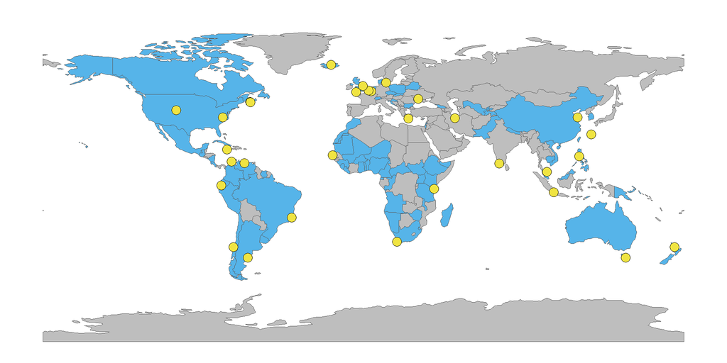

## What are GBIF-US and OBIS-USA?

USGS-SAS Biogeographic Science Branch manages the US nodes: GBIF-US and OBIS-USA.

- represent US interests in the international initiatives
- advise the US scientific community on biodiversity informatics, data, and standards
- mobilize and synthesize data to enhance its FAIRness and relevance on national and international scales.

We also manage the [OBIS-USA](https://ipt-obis.gbif.us/) and [GBIF-US](https://ipt.gbif.us/) Integrated Publishing Toolkits (IPTs)!

## Why do we work with GBIF and OBIS?

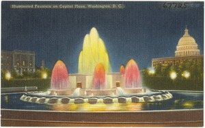

*Sparkly fountains need robust plumbing systems.*  
- Terry McConnell (International Digital Twins of the Ocean Summit 2022)

The US has been a voting participant in GBIF since 2001 and became an OBIS-USA node in 2005.

The USGS is shepherding over two decades of investment in the robust plumbing needed for national and global biodiversity science and data.

## How are GBIF and OBIS the same?

Both are active and energetic communities that develop, maintain, and promote standards and practices for biodiversity science and have been doing so for > 20 years

Both promote open data and science, and publish massive amounts of standardized biological observations through their platforms

Have signed a [letter of agreement](https://www.gbif.org/news/6M8YYYirX3bK57bHaIpd0U/ocean-biodiversity-information-system-and-gbif-update-and-expand-cooperation-agreement) in recognition that their respective communities will benefit from more streamlined ways of working together. A stronger action plan is forthcoming.

GBIF and OBIS are built on the same data and metadata standards, and share open-source tools

## Important Differences

GBIF has a global scope. OBIS includes marine occurrences only.

GBIF is funded by individual participant countries. We fund GBIF-US through the NSF. OBIS is funded by UNESCO, an agency of the United Nations.

GBIF-US and OBIS-USA are unusual in that both nodes are managed by the same people.

## How does it work?

[figure not shown]

This is an illustration of the GBIF workflow. The OBIS workflow is similar.

## What do GBIF and OBIS do well?

- Coordinate and serve interoperable observations of biological occurrence
- Promote and catalyze progress for open science and FAIR data
- Searching data at the occurrence level
- Track data use and [citations](https://www.gbif.org/literature-tracking)
- Well designed tools and guidance exist for self-publishing
- Active and diverse community

## Things in Development

- Taxonomic alignment
- Facilitating round tripping of data, taxonomic updates
- Sequence searches
- [eDNA publishing tools](https://edna-tool.gbif-uat.org/) for non-technical / small-to-medium publishers
- Expansion of US node staff

## So, why use GBIF and OBIS?

Off-the-shelf platforms for publishing and tracking use of biological occurrence data with minimal financial or staffing investment. USGS, and SpringerNature, accept GBIF as an archival repository, publishing to OBIS-USA satisfies NOAA archiving requirements.

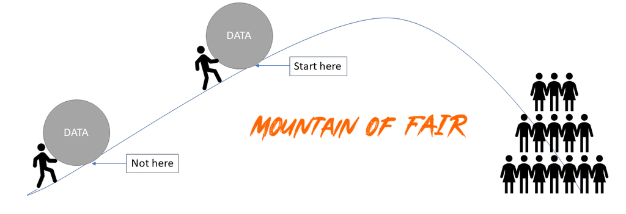

## Sustainablity - International

Both organizations rely on regular international investment for funding.

OBIS recently transitioned from an IODE project to a program, which means it now receives core funding and staff support to enable the activity to operate on a permanent basis.

Open standards and science means that migration of data would be relatively simple in the event of a surprise shutdown.

## Sustainablity - US

GBIF-US is funded by NSF (~ $600k / year). There is a [US Delegation](https://www.gbif.us/community/) that guides GBIF for US interests.

For operation of both nodes, USGS funds the node staff salary + travel. NOAA IOOS also contributes staff to OBIS-USA.

Both IPTs could easily transition to other management and continue to operate without US funding

Both secretariats have funding and training in place for new nodes and node managers

# Publishing Data

```
flowchart TB

    collect("Collect Data")
    align("Align to Darwin Core")
    create("Create a Darwin Core Archive (DwC-A)")
    register("Register DwC-A with OBIS/GBIF")

    collect-->align-->create-->register
```

## DNA-Derived Data

[figure not shown]

https://docs.gbif.org/publishing-dna-derived-data/img/web/sampling-processes.en.svg

## Two Standards

1. [Darwin Core (DwC)](https://dwc.tdwg.org/terms/): Describe your biological observation.
2. [Ecological Metadata Language (EML)](https://eml.ecoinformatics.org/): Describe your dataset.

## The Darwin Core Archive (DwC-A)

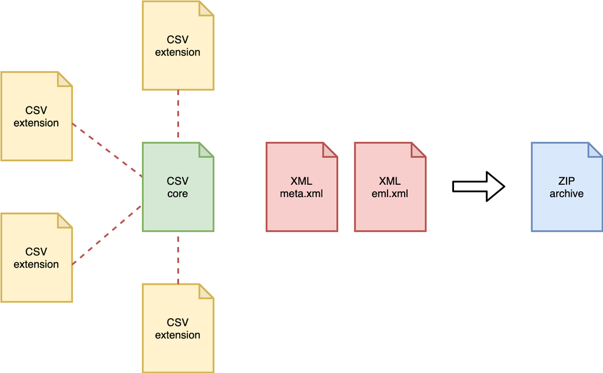

## The DNADerivedData extension

The [DNADerivedData extension](https://rs.gbif.org/extension/gbif/1.0/dna_derived_data_2022-02-23.xml) extends occurrence data with molecular biology metadata.

It mostly consists of terms from:

- GGBN Data Standard
- GSC MIxS (Minimum Information about any (X) Sequence)
- MIQE (The Minimum Information for Publication of Quantitative Real-Time PCR Experiments).

Guidance is available: [Publishing DNA-derived data through biodiversity data platforms](https://docs.gbif.org/publishing-dna-derived-data/en/). The guide handles barcoding, metabarcoding, metagenomics and qPCR/ddPCR.

[figure not shown]

## Examples from [Silliman et al., 2023](https://obis.org/dataset/210efc7c-4762-47ee-b4b5-22a0f436ef44)

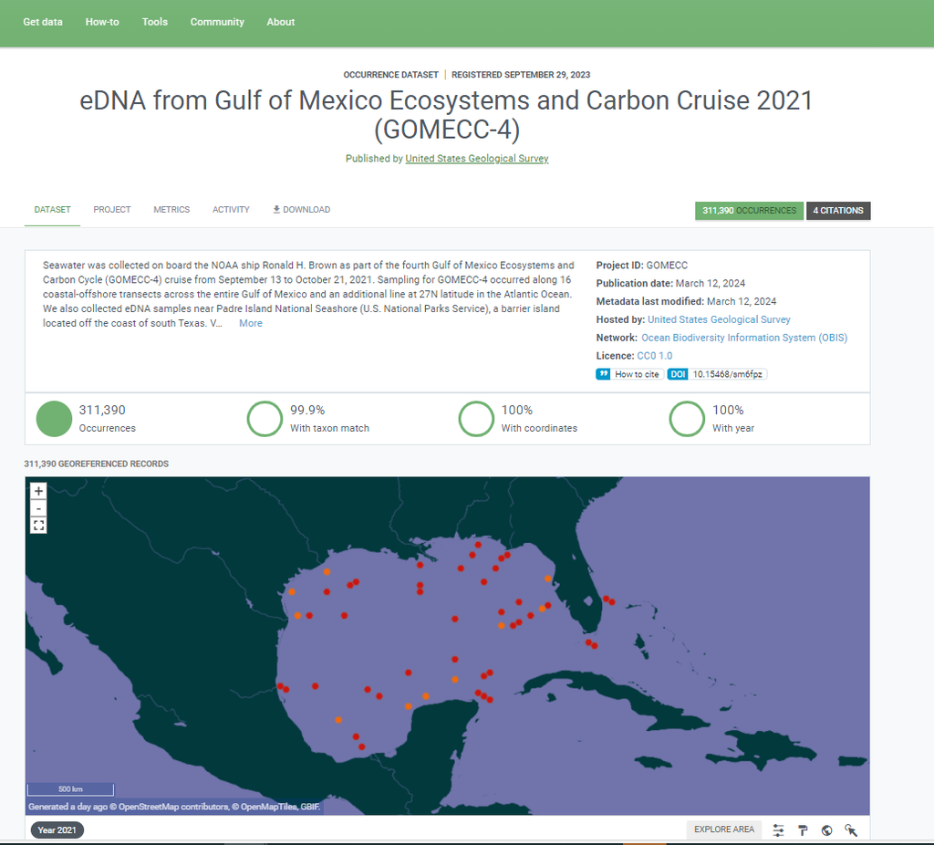

[figure not shown]

## Examples of DwC Terms

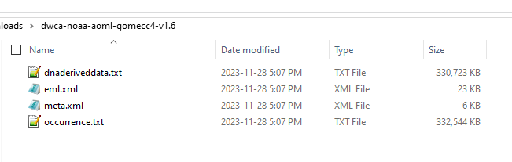

Silliman et al. Darwin Core Archive shown through file explorer. *647 MB unzipped.*

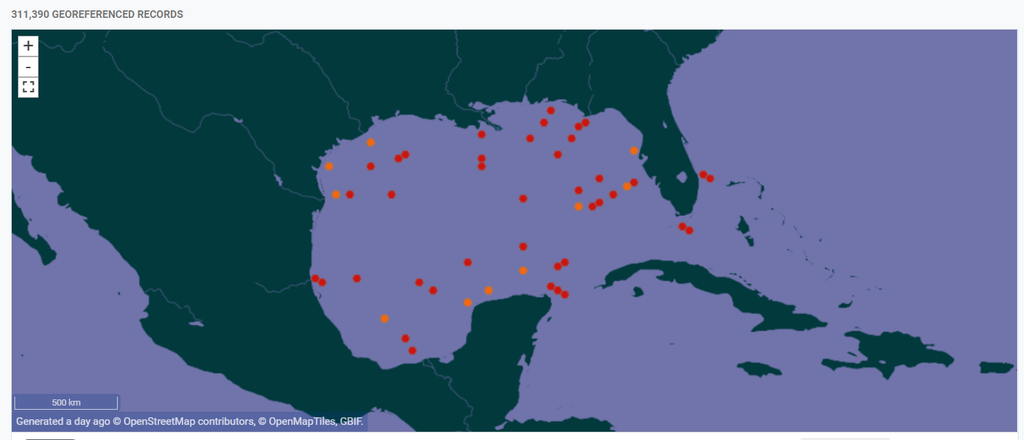

Map of Silliman et al.

## Examples of DwC Terms

Table 1: Example Occurrence Data From [Silliman et al., 2023](https://obis.org/dataset/210efc7c-4762-47ee-b4b5-22a0f436ef44)

| Term | Example |
| --- | --- |
| occurrenceID | GOMECC4_PANAMACITY_Sta21_DCM_A_occ7c8b2f5e16137114160dfd4001f67550 |
| eventDate | 2021-09-20T18:04-04:00 |
| locality | USA: Gulf of Mexico |
| locationID | PANAMACITY_Sta21 |
| decimalLatitude | 29.206 |
| decimalLongitude | -85.647 |
| geodeticDatum | WGS84 |
| minimumDepthInMeters | 39 |
| maximumDepthInMeters | 39 |

## Examples of DwC Terms

Table 2: Example Occurrence Data From [Silliman et al., 2023](https://obis.org/dataset/210efc7c-4762-47ee-b4b5-22a0f436ef44)

| Term | Example |
| --- | --- |
| occurrenceID | GOMECC4_PANAMACITY_Sta21_DCM_A_occ7c8b2f5e16137114160dfd4001f67550 |
| basisOfRecord | MaterialSample |
| organismQuantity | 35 |
| organismQuantityType | DNA sequence reads |
| sampleSizeValue | 12436 |
| sampleSizeUnit | DNA sequence reads |
| associatedSequences | https://www.ncbi.nlm.nih.gov/sra/SRR26161072 \| https://www.ncbi.nlm.nih.gov/biosample/SAMN37516159 \| https://www.ncbi.nlm.nih.gov/bioproject/PRJNA887898 |
| identificationRemarks | Tourmaline; qiime2-2021.2; naive-bayes classifier, confidence (at lowest specified taxon): 0.966508279, against reference database: PR2 v5.0.1; V9 1391f-1510r region; 10.5281/zenodo.8392706. The PR2 d… |
| verbatimIdentification | Karenia brevis |
| scientificName | Karenia brevis |
| scientificNameID | urn:lsid:marinespecies.org:taxname:233015 |

## Examples of DwC Terms

Table 3: Example Occurrence Data (ambiguous taxonomy) From [Silliman et al., 2023](https://obis.org/dataset/210efc7c-4762-47ee-b4b5-22a0f436ef44)

| Term | Example |
| --- | --- |
| occurrenceID | GOMECC4_YUCATAN_Sta100_Surface_B_occ1f111363da96fee3d180ddb12741d4ce |
| basisOfRecord | MaterialSample |
| organismQuantity | 18 |
| organismQuantityType | DNA sequence reads |
| sampleSizeValue | 12151 |
| sampleSizeUnit | DNA sequence reads |
| associatedSequences | https://www.ncbi.nlm.nih.gov/sra/SRR26160967 \| https://www.ncbi.nlm.nih.gov/biosample/SAMN37516435 \| https://www.ncbi.nlm.nih.gov/bioproject/PRJNA887898 |
| identificationRemarks | Tourmaline; qiime2-2021.2; naive-bayes classifier, confidence (at lowest specified taxon): 0.960018364, against reference database: PR2 v5.0.1; V9 1391f-1510r region; 10.5281/zenodo.8392706. The PR2 d… |
| verbatimIdentification | Unassigned |
| scientificName | Biota incertae sedis |
| scientificNameID | urn:lsid:marinespecies.org:taxname:12 |

## Examples of DwC Terms

Table 4: Example Occurrence Data From [Silliman et al., 2023](https://obis.org/dataset/210efc7c-4762-47ee-b4b5-22a0f436ef44)

| Term | Example |
| --- | --- |
| occurrenceID | GOMECC4_PANAMACITY_Sta21_DCM_A_occ7c8b2f5e16137114160dfd4001f67550 |
| DNA_sequence | GCTCCTACCGATTGAGTGATCCGGTGAATAATTCGGACTGCCGCAGTGTTCAGATCCTGAACGTTGCAGTGGAAAGTTTAGTGAACCTTATCACTTAGAGGAAGGAGAAGTCGTAACAAGGTTTCC |
| concentration | 1.177 |
| target_gene | 18S rRNA |
| target_subfragment | V9 |
| pcr_primer_forward | GTACACACCGCCCGTC |
| pcr_primer_reverse | TGATCCTTCTGCAGGTTCACCTAC |
| pcr_primer_name_forward | 1391f |
| pcr_primer_name_reverse | EukBr |
| pcr_primer_reference | 10.1371/journal.pone.0006372 |
| seq_meth | Illumina MiSeq 2x250 |
| otu_class_appr | Tourmaline; qiime2-2021.2; dada2; ASV |
| otu_db | PR2 v5.0.1; V9 1391f-1510r region; 10.5281/zenodo.8392706 |
| otu_seq_comp_appr | Tourmaline; qiime2-2021.2; naive-bayes classifier |

You don’t have to use OBIS/GBIF.

## So, why use GBIF and OBIS?

Off-the-shelf platforms for publishing and tracking use of biological occurrence data with minimal financial or staffing investment.

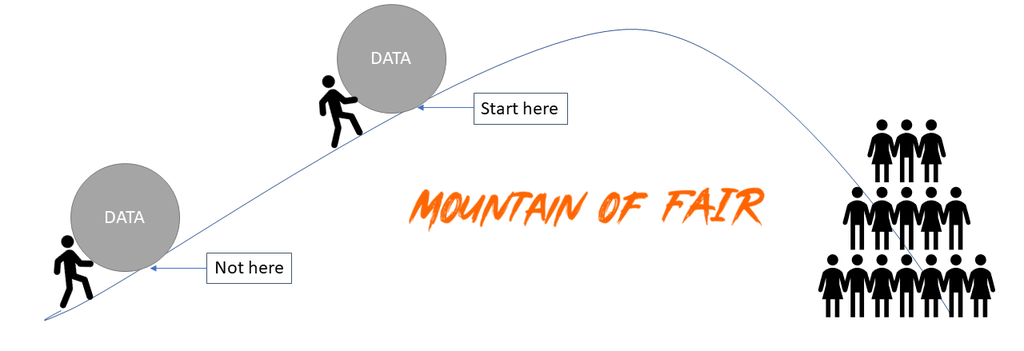

## Thank you!

Compliments? Complaints? Ideas?

sformel@usgs.gov

[figure not shown]

presented as a NOAA Omics Seminar 2024-04-17